# This is a national broadcasted tutorial presented to you by

# Franchise Psycho

[figure not shown]

```python
r = requests.get('https://www.boxofficemojo.com/franchise/fr2873593605/?ref_=bo_frs_table_220')
soup = BeautifulSoup(r.content)
col = soup.find('table')
opening = col.find_all('td',class_ = 'a-text-right mojo-field-type-money')
lifetime = col.find_all('td',class_ = 'a-text-right mojo-field-type-money mojo-sort-column mojo-estimatable')
names = col.find_all('td',class_ = 'a-text-left mojo-field-type-release mojo-cell-wide')
dates = col.find_all('td',class_ = 'a-text-left mojo-field-type-date a-nowrap')

name = []
life = []
opn = []
date = []
for i in names:
    name.append(i.text)
for i in lifetime:
    life.append(i.text)
for i in opening:
    opn.append(i.text)
for i in dates:
    date.append(i.text)

table = pd.DataFrame(data = [], columns = ["name","Date","open","life"])
table["name"] = name
table["open"] = life
table["life"] = opn
table["Date"] = date
table.Date = pd.to_datetime(table.Date)
table = table.sort_values(by = "Date")
table
```

|  | name | Date | open | life |
| --- | --- | --- | --- | --- |
| 1 | Psycho | 1960-06-16 | $32,000,000 | - |
| 0 | Psycho II | 1983-06-03 | $34,725,000 | $8,310,244 |
| 3 | Psycho III | 1986-07-04 | $14,481,606 | $3,238,400 |
| 2 | Psycho | 1998-12-04 | $21,485,655 | $10,031,850 |

```python
b = table.open
b = b.str.replace(r'$','')
b = b.str.replace(r',','')
a = np.array(b)
Diff_array.append(abs(int(a[len(a)-1]) - int(a[0])))
num1 = int(a[len(a)-1])
num2 = int(a[0])
per_array.append(round(((num2 - num1)/num2) *100,3))
```

# Franchise Kong

[figure not shown]

```python
r = requests.get('https://www.boxofficemojo.com/franchise/fr910659333/?ref_=bo_frs_table_66')
soup = BeautifulSoup(r.content)
col = soup.find('table')
opening = col.find_all('td',class_ = 'a-text-right mojo-field-type-money')
lifetime = col.find_all('td',class_ = 'a-text-right mojo-field-type-money mojo-sort-column mojo-estimatable')
names = col.find_all('td',class_ = 'a-text-left mojo-field-type-release mojo-cell-wide')
dates = col.find_all('td',class_ = 'a-text-left mojo-field-type-date a-nowrap')

name = []
life = []
opn = []
date = []
for i in names:
    name.append(i.text)
for i in lifetime:
    life.append(i.text)
for i in opening:
    opn.append(i.text)
for i in dates:
    date.append(i.text)

table = pd.DataFrame(data = [], columns = ["name","Date","open","life"])
table["name"] = name
table["open"] = life
table["life"] = opn
table["Date"] = date
table.Date = pd.to_datetime(table.Date)
table = table.sort_values(by = "Date")
table = table.drop([6,5,1,2])
table
```

|  | name | Date | open | life |
| --- | --- | --- | --- | --- |
| 3 | King Kong | 1976-12-17 | $52,614,445 | $7,023,921 |
| 4 | King Kong Lives | 1986-12-19 | $4,711,220 | $1,172,942 |
| 0 | King Kong | 2005-12-14 | $218,080,025 | $50,130,145 |

```python
b = table.open
b = b.str.replace(r'$','')
b = b.str.replace(r',','')
a = np.array(b)
Diff_array.append(abs(int(a[len(a)-1]) - int(a[0])))
num1 = int(a[len(a)-1])
num2 = int(a[0])

per_array.append(round(((num1 - num2)/num1) *100,3))
```

```python
fran_table = pd.DataFrame(data = [], columns = ["Franchise","Amount diff","%","Year Diff"])
fran_table["Franchise"] = ["Marvel", "X-Men", "James Bond", "Men In Black","THe Omen","Psyco","King Kong"]
fran_table["Amount diff"] = Diff_array
fran_table['%'] = per_array
fran_table["Year Diff"] = [11,20,36,22,30,38,29,]
fran_table
```

|  | Franchise | Amount diff | % | Year Diff |
| --- | --- | --- | --- | --- |
| 0 | Marvel | 71927959 | 18.418 | 11 |
| 1 | X-Men | 133447059 | 84.836 | 20 |
| 2 | James Bond | 129766510 | 64.859 | 36 |
| 3 | Men In Black | 170688732 | 68.087 | 22 |
| 4 | THe Omen | 6315597 | 10.367 | 30 |
| 5 | Psyco | 10514345 | 32.857 | 38 |
| 6 | King Kong | 165465580 | 75.874 | 29 |

```
<function matplotlib.pyplot.show(close=None, block=None)>
```

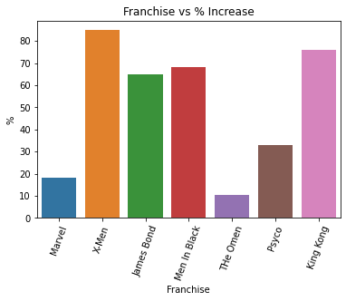

```python
ax = sns.barplot(x="Franchise", y="%", data=fran_table)
ax.set_title("Franchise vs % Increase")
plt.xticks(rotation=70)
plt.show
```

# A look at other countries

In this section we will look at two continents which are Europe and Asia. These two continent are next on the list of movie success's. We are not going to be looking at every country but only a few. We will observe France, United Kingdom, and Germany for Europe, and China and India for Asia.

# France

```python
url1 = "https://en.wikipedia.org/wiki/List_of_highest-grossing_films_in_France"
web = requests.get(url =url1)
b = BeautifulSoup(web.content)

t1 = b.find_all('table', class_='wikitable sortable')
valu = t1[1].tbody.text
sp = valu.split('\n\n\n')

col = []
for i in sp:
    col.append(i.split('\n\n'))

col[100].remove('')
col.pop(0)
```

```
['\nRank', 'Title', 'Tickets Sold[1]', 'Year[4]']
```

```python
france= pd.DataFrame(col, columns = ["rank","Title", "Tickets Sold" ,"Year"])
france.sort_values(by = 'Title', inplace=True)
france = france.reset_index(drop=True)
y =list(france.Title)
france
```

|  | rank | Title | Tickets Sold | Year |
| --- | --- | --- | --- | --- |
| 0 | 21 | Amélie | 8,636,041 | 2001 |
| 1 | 70 | Andalousie | 5,735,113 | 1951 |
| 2 | 52 | Arthur and the Invisibles | 6,396,989 | 2006 |
| 3 | 17 | Asterix & Obelix Take On Caesar | 8,948,624 | 1999 |
| 4 | 4 | Asterix & Obelix: Mission Cleopatra | 14,559,509 | 2002 |
| ... | ... | ... | ... | ... |
| 95 | 24 | Violettes impériales | 8,125,766 | 1952 |
| 96 | 13 | War of the Buttons | 9,936,391 | 1962 |
| 97 | 90 | fr:La Bataille de l'eau lourde | 5,373,377 | 1948 |
| 98 | 53 | fr:La Cuisine au beurre | 6,396,529 | 1963 |
| 99 | 73 | À nous les petites Anglaises | 5,704,446 | 1977 |

100 rows × 4 columns

We manage to find some of the best french movies. These are the top 100 french movies with the most success in the country. Next step will be to find which ones have sequels, so we can apply our analysis.

```python
col2 = []
j = 0
for i in y:
    col2.append([j,i])
    j=j+1
col2
france2 = france[ (france.index==3) | (france.index==4)  |  (france.index==5)  |  (france.index==38)  |  (france.index==39)  |  (france.index==48)  |  (france.index==67)  |  (france.index==68)  |  (france.index==74)  |  (france.index==75) |  (france.index==76) | (france.index==91) ]

cat = ['Original','before 7 years','Late','Original','Late','Original','Original','before 7 years','Original','before 7 years','before 7 years','before 7 years']
cat2=['Original','Sequels','Sequels','Original','Sequels','Original','Original','Sequels','Original','Sequels','Sequels','Sequels']
france2.insert(4, "category of sequel", cat, True)
france2.insert(5, "original or sequel", cat2, True)

france2 = france2.reset_index(drop=True)

r = list(france2['Tickets Sold'])
r2= list(france2['Year'])
col3 =[]
col4=[]
for i in r:
    stri = str(i)
    stri = stri.replace(',','')
    col3.append(int(stri))

col3

for i in r2:
    col4.append(int(i))

france2.pop('Tickets Sold')
france2.pop('Year')

france2.insert(2, "Tickets Sold", col3, True)
france2.insert(3, "Year", col4, True)
france2
```

|  | rank | Title | Tickets Sold | Year | category of sequel | original or sequel |
| --- | --- | --- | --- | --- | --- | --- |
| 0 | 17 | Asterix & Obelix Take On Caesar | 8948624 | 1999 | Original | Original |
| 1 | 4 | Asterix & Obelix: Mission Cleopatra | 14559509 | 2002 | before 7 years | Sequels |
| 2 | 45 | Asterix at the Olympic Games | 6817803 | 2008 | Late | Sequels |
| 3 | 56 | Le gendarme et les extra-terrestres | 6280070 | 1979 | Original | Original |
| 4 | 44 | Le gendarme se marie | 6828626 | 1968 | Late | Sequels |
| 5 | 5 | Les Visiteurs | 13782991 | 1993 | Original | Original |
| 6 | 48 | Qu'est-ce qu'on a encore fait au Bon Dieu ? | 6711618 | 2019 | Original | Original |
| 7 | 7 | Qu'est-ce qu'on a fait au Bon Dieu ? | 12366033 | 2014 | before 7 years | Sequels |
| 8 | 51 | Taxi | 6522121 | 1998 | Original | Original |
| 9 | 10 | Taxi 2 | 10345901 | 2000 | before 7 years | Sequels |
| 10 | 60 | Taxi 3 | 6151691 | 2003 | before 7 years | Sequels |
| 11 | 25 | The Visitors II: The Corridors of Time | 8043129 | 1998 | before 7 years | Sequels |

From the top 100 best French movies, we managed to get 5 movies that have sequels. Apparently, France is not a fan of sequels. In this table above, we have categorized which movies are late sequels and which one are early sequels. Although the sample is small we will try to see which one of the two categories do better. We have also created an other column showing whether the movie is an original or a squel.

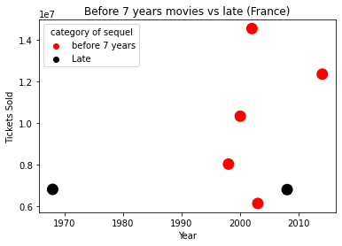

```python
france3 = france2[(france2['category of sequel']=='before 7 years') | (france2['category of sequel']=='Late')]

sns.scatterplot(x='Year', y='Tickets Sold', hue='category of sequel',data=france3, s=200, palette=['red','black'])
plt.title('Before 7 years movies vs late (France)')
plt.show()
```

# United Kingdom

In this section, we will be looking at movie squels that qualify as made by British production. This data also include squels which were made by british production, but whose original wasn't. This data was retrieved from https://en.wikipedia.org/wiki/List_of_highest-grossing_films_in_the_United_Kingdom and https://www.the-numbers.com/United-Kingdom/movies#tab=year

```python
data_uk = [['The inbetweeners Movie',45.7, 2011],['The inbetweeners', 45, 2014], ['Harry Potter and the chamber of Secrets', 54.9, 2002], ['Fantastic Beasts and Where to find Them',54.7,2016], ['Harry Potter and the half-blood Prince', 50.9,2009], ['Harry potter and the Order of the Phoenix', 50, 2007], ['Harry Potter and the Gobet of Fire', 49.2,2005], ['Harry Potter and the Prisoner of Azkaban', 46.2, 2004], ['Harry Potter and the Deathly Hallows-Part 2', 73.1, 2011], ['Harry Potter and the Philosopher Stone', 65.8, 2001], ['Skyfall', 103.2, 2012], ['Spectre', 95.2,2015],['Casino Royale', 66.0, 2006],['Star Wars: The Rise of Skywalker', 58.3, 2019], ['Star wars: The Force Awakens', 123.2, 2015]]
uk = pd.DataFrame(data_uk, columns = ["Title", "Gross" ,"Year"])

cat5 = ['Original','before 7 years','before 7 years','before 7 years','before 7 years','before 7 years','before 7 years','before 7 years','before 7 years','Original','before 7 years','before 7 years','late', 'before 7 years', 'late']


uk.insert(3, "Category of the sequel", cat5, True)
uk = uk[uk['Category of the sequel']!='Original']
uk
```

|  | Title | Gross | Year | Category of the sequel |
| --- | --- | --- | --- | --- |
| 1 | The inbetweeners | 45.0 | 2014 | before 7 years |
| 2 | Harry Potter and the chamber of Secrets | 54.9 | 2002 | before 7 years |
| 3 | Fantastic Beasts and Where to find Them | 54.7 | 2016 | before 7 years |
| 4 | Harry Potter and the half-blood Prince | 50.9 | 2009 | before 7 years |
| 5 | Harry potter and the Order of the Phoenix | 50.0 | 2007 | before 7 years |
| 6 | Harry Potter and the Gobet of Fire | 49.2 | 2005 | before 7 years |
| 7 | Harry Potter and the Prisoner of Azkaban | 46.2 | 2004 | before 7 years |
| 8 | Harry Potter and the Deathly Hallows-Part 2 | 73.1 | 2011 | before 7 years |
| 10 | Skyfall | 103.2 | 2012 | before 7 years |
| 11 | Spectre | 95.2 | 2015 | before 7 years |
| 12 | Casino Royale | 66.0 | 2006 | late |
| 13 | Star Wars: The Rise of Skywalker | 58.3 | 2019 | before 7 years |
| 14 | Star wars: The Force Awakens | 123.2 | 2015 | late |

After doing a lot of research on movies produced by British production, we managed to find only 2 that were late sequels. Many sequels were below 7 years since their original were released.

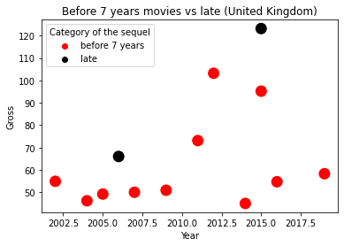

```python
sns.scatterplot(x='Year', y='Gross', hue='Category of the sequel',data=uk, s=200, palette=['red','black'])
plt.title('Before 7 years movies vs late (United Kingdom)')
plt.show()
```

It will not be correct to fully establish a conclusion based on this chart. This graph seems to be showing that late sequels do better than close sequels (released before 7 years of their predecessors). The issue is that there are way more sequels that were released before reaching a 7-year time difference with their predecessors than there are late sequels. Therefore, we cannot fully assume that late sequels do better.

# Germany

The data below was retrieved from https://en.wikipedia.org/wiki/Category:German_sequel_films and https://www.the-numbers.com/custom-search

```python
last=[['Fack ju Gohte 2', 406331564,2015, 'earlier'],['Fack ju Gohte 3', 287495874,2017, 'earlier' ], ['Resident Evil: Afterlife', 523938808, 2015,'earlier'], ['The Mummy:Tom of the Dragon Emperor', 1002939878, 2008,'late'], ['AVP: Alien Vs. Predrator', 661628942,2004, 'late'], ['Basic instinct 2', 38600000, 2006,'late'],
      ['The Girl in the Spider\'s Web', 34983342,2018, 'late'],['Die Ruckkehr der Liebenden', 765033,1991, 'late'],  ['The Bourne Supremacy',290600000, 2004,'earlier']]

germany = pd.DataFrame(last, columns = ["Title", "Gross" ,"Year", 'Category of sequels'])
germany
```

|  | Title | Gross | Year | Category of sequels |
| --- | --- | --- | --- | --- |
| 0 | Fack ju Gohte 2 | 406331564 | 2015 | earlier |
| 1 | Fack ju Gohte 3 | 287495874 | 2017 | earlier |
| 2 | Resident Evil: Afterlife | 523938808 | 2015 | earlier |
| 3 | The Mummy:Tom of the Dragon Emperor | 1002939878 | 2008 | late |
| 4 | AVP: Alien Vs. Predrator | 661628942 | 2004 | late |
| 5 | Basic instinct 2 | 38600000 | 2006 | late |
| 6 | The Girl in the Spider's Web | 34983342 | 2018 | late |
| 7 | Die Ruckkehr der Liebenden | 765033 | 1991 | late |
| 8 | The Bourne Supremacy | 290600000 | 2004 | earlier |

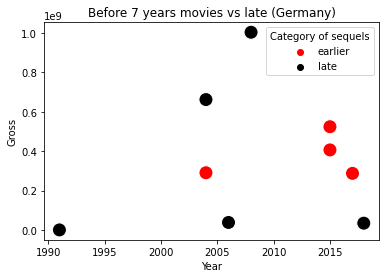

```python
sns.scatterplot(x='Year', y='Gross', hue='Category of sequels',data=germany, s=200, palette=['red','black'])
plt.title('Before 7 years movies vs late (Germany)')
plt.show()
```

This plot of Germany is more balance than the ones from France and the UK. The number of late sequels is almost the same as the sequels that were released before the 7-year time difference with their predecessor. If we observe late sequels, we can see that some late sequels do very good, and some others do very bad. On the other hand, when we observe earlier sequels, their results are more moderated. The earlier sequels do good in Germany but not great. After this analysis, i can estimate that the result is balance.

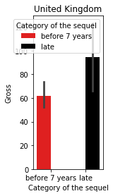

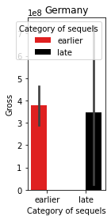

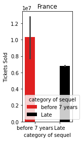

```python
plt.subplot(1,3,1)
sns.barplot(x='Category of the sequel', y='Gross', hue='Category of the sequel',data=uk, palette=['red','black'])
plt.title('United Kingdom')
plt.show()

plt.subplot(1,3,2)
sns.barplot(x='Category of sequels', y='Gross', hue='Category of sequels',data=germany, palette=['red','black'])
plt.title('Germany')
plt.show()

plt.subplot(1,3,3)
sns.barplot(x='category of sequel', y='Tickets Sold', hue='category of sequel',data=france3, palette=['red','black'] )
plt.title('France')
plt.show()
```

Let try a deeper observation of the 3 countries. Above are 3 plots representing each of the 3 countries that we observed in this section. The plots represent the average amount of money each of the 2 groups (late and earlier sequels) made in their country. With this we can confirm are previous observations. If we look at the UK plot, we can see that we were right. We estimated that the fact that there was more earlier sequels and very few late sequels (2) was going to give us the assumption that late sequels do better than earlier sequels. For France, it was obvious that earlier sequels do better than late ones. With Germany it was a bit tricky. We assumed that earlier sequels and late sequels were going to be balanced. We were not fully wrong. the group are almost balance with earlier sequels doing a little better than later ones.

# **Asia**

## Building the Table for Indian Movies

We are starting with creating a list of movie titles for each series of movies as well as a list of their corresponding release date and gross. list1 through list7 contains series titles and each list is followed by a list with the movie's corresponding release year and gross.

The purpose of creating this table is to have organize the movies' relevant information in order to analyze how different sequel release timing affects the success (determined by the gross) of the sequel.

India's movie data retrieved from: boxofficeindia.com

```python
india_sequels = ["Dabangg 2", "Dabangg 3", "Dhoom 2", "Dhoom 3", "Housefull 2", "Housefull 3", "Housefull 4"
        ,"Aheb Biwi Aur Gangster Returns", "Aheb Biwi Aur Gangster 3", "Pyaar Ka Punchnama 2"
        , "Golmaal Returns", "Golmaal 3", "Satya 2"]


# list1 through list7 each have a different seriese
# years1 through years7 each have the corresponding series' release year
# gross1 through gross7 each contain the corresponding series' gross


list1 = ["Dabangg", "Dabangg 2", "Dabangg 3"]
years1 = [2010, 2012, 2019]
gross1 = [1933700000, 2026500000, 1610600000]

list2 = ["Dhoom", "Dhoom 2", "Dhoom 3"]
years2 = [2004, 2006, 2013]
gross2 = [465800000, 1139200000, 3487300000]


list3 = ["Housefull", "Housefull 2", "Housefull 3", "Housefull 4"]
years3 = [2010, 2012, 2016, 2019]
gross3 = [983700000, 1537600000, 1505500000, 2475200000]

list4 = ["Aheb Biwi Aur Gangster", "Aheb Biwi Aur Gangster Returns", "Aheb Biwi Aur Gangster 3"]
years4 = [2011, 2013, 2018]
gross4 = [102600000, 287200000, 93000000]

list5 = ["Pyaar Ka Punchnama", "Pyaar Ka Punchnama 2" ]
years5 = [2011, 2015]
gross5 = [170300000, 834500000]

list6 = ["Golmaal", "Golmaal Returns", "Golmaal 3"]
years6 = [2006, 2008, 2010]
gross6 = [414900000, 708900000, 1491200000]

list7 = ["Satya", "Satya 2"]
years7 = [1998, 2013]
gross7 = [184700000, 28400000]


# Concatenating the series above and building the table

indian_movies = list1 + list2 + list3 + list4 + list5 + list6 + list7
grossed = gross1 + gross2 + gross3 + gross4 + gross5 + gross6 + gross7
released = years1 + years2 + years3 + years4 + years5 + years6 + years7

ID_table = pd.DataFrame(indian_movies, columns = ["Title"])
ID_table["Year"] = released
ID_table["Gross"] = grossed

ID_table
```

|  | Title | Year | Gross |
| --- | --- | --- | --- |
| 0 | Dabangg | 2010 | 1933700000 |
| 1 | Dabangg 2 | 2012 | 2026500000 |
| 2 | Dabangg 3 | 2019 | 1610600000 |
| 3 | Dhoom | 2004 | 465800000 |
| 4 | Dhoom 2 | 2006 | 1139200000 |
| 5 | Dhoom 3 | 2013 | 3487300000 |
| 6 | Housefull | 2010 | 983700000 |
| 7 | Housefull 2 | 2012 | 1537600000 |
| 8 | Housefull 3 | 2016 | 1505500000 |
| 9 | Housefull 4 | 2019 | 2475200000 |
| 10 | Aheb Biwi Aur Gangster | 2011 | 102600000 |
| 11 | Aheb Biwi Aur Gangster Returns | 2013 | 287200000 |
| 12 | Aheb Biwi Aur Gangster 3 | 2018 | 93000000 |
| 13 | Pyaar Ka Punchnama | 2011 | 170300000 |
| 14 | Pyaar Ka Punchnama 2 | 2015 | 834500000 |
| 15 | Golmaal | 2006 | 414900000 |
| 16 | Golmaal Returns | 2008 | 708900000 |
| 17 | Golmaal 3 | 2010 | 1491200000 |
| 18 | Satya | 1998 | 184700000 |
| 19 | Satya 2 | 2013 | 28400000 |

Now that we have a table of the relevant data where we can clearly see each movie's release date and year, we can do some calculations to get the time gap between each movie and its sequel. For example, the time between the movie Dabangg and Dabangg 2, and the time between Dabangg 2 and Dabangg 3. We'll do this for each movie and its sequel and store the time gaps in a list.

This will be done one series at a time as each series can be a different size. While getting the time gap, we will also calculate the gross increase percentage and append that to a list as well.

```python
change_list = [] # This list will contain the percentage of gross increase between a movie and its sequel
year_gap = []    # year_gap will contain a list of time gaps between movies and their sequels

#Finding the gross difference example: first sequel - original movie, and second sequel - first sequel

# Each for loop is for a series. Each series is a different size so multiple for loops are
# needed to neatly compute the time gaps and increase percentages.

# Dabangg series
for i in range(1, 3):
    gross_diff = gross1[i] - gross1[i-1]
    year_gap.append(years1[i] - years1[i-1])
    increase = (gross_diff * 100) / gross1[i-1]
    change_list.append(increase)

# Dhoom Series
for i in range(1, 3):
    gross_diff = gross2[i] - gross2[i-1]
    year_gap.append(years2[i] - years2[i-1])
    increase = (gross_diff * 100) / gross2[i-1]
    change_list.append(increase)

# Housefull series
for i in range(1, 4):
    gross_diff = gross3[i] - gross3[i-1]
    year_gap.append(years3[i] - years3[i-1])
    increase = (gross_diff * 100) / gross3[i-1]
    change_list.append(increase)

# Aheb Biwi Aur Gangster series
for i in range(1, 3):
    gross_diff = gross4[i] - gross4[i-1]
    year_gap.append(years4[i] - years4[i-1])
    increase = (gross_diff * 100) / gross4[i-1]
    change_list.append(increase)

# Pyaar Ka Punchnama series
for i in range(1, 2):
    gross_diff = gross5[i] - gross5[i-1]
    year_gap.append(years5[i] - years5[i-1])
    increase = (gross_diff * 100) / gross5[i-1]
    change_list.append(increase)

# Golmaal series
for i in range(1, 3):
    gross_diff = gross6[i] - gross6[i-1]
    year_gap.append(years6[i] - years6[i-1])
    increase = (gross_diff * 100) / gross6[i-1]
    change_list.append(increase)

# Satya series
for i in range(1, 2):
    gross_diff = gross7[i] - gross7[i-1]
    year_gap.append(years7[i] - years7[i-1])
    increase = (gross_diff * 100) / gross7[i-1]
    change_list.append(increase)


change_list
```

```
[4.799089827791281,
 -20.523069331359487,
 144.56848432803778,
 206.1183286516854,
 56.30781742401138,
 -2.087669094693028,
 64.41049485220857,
 179.92202729044834,
 -67.61838440111421,
 390.01761597181445,
 70.86044830079537,
 110.35406968542813,
 -84.62371413102328]
```

*The* list displayed above called change_list shows the gross increase percentage from a prequel to its sequel, in the same order that the corresponding sequel films are placed in the ID_table data frame. This will be used as a column for another dataframe.

Since this list contains percentage of gross increase between two movies, we don't have to include the orginial movies of the series in our new table. This is were we will use the list called india_sequels we made in the beginning, which only contains sequels.

```python
india_df = pd.DataFrame(india_sequels, columns = ["Sequels"])
india_df["Increase"] = change_list
india_df["year_gap"] = year_gap
categ = []

# Categorizing year gap as "Before 7 years" or "Late"
for i in range(0, len(india_df)):
    if india_df.year_gap[i] >= 7:
        categ.append("Late")
    else:
        categ.append("Earlier")

india_df["category"] = categ
india_df
```

|  | Sequels | Increase | year_gap | category |
| --- | --- | --- | --- | --- |
| 0 | Dabangg 2 | 4.799090 | 2 | Earlier |
| 1 | Dabangg 3 | -20.523069 | 7 | Late |
| 2 | Dhoom 2 | 144.568484 | 2 | Earlier |
| 3 | Dhoom 3 | 206.118329 | 7 | Late |
| 4 | Housefull 2 | 56.307817 | 2 | Earlier |
| 5 | Housefull 3 | -2.087669 | 4 | Earlier |
| 6 | Housefull 4 | 64.410495 | 3 | Earlier |
| 7 | Aheb Biwi Aur Gangster Returns | 179.922027 | 2 | Earlier |
| 8 | Aheb Biwi Aur Gangster 3 | -67.618384 | 5 | Earlier |
| 9 | Pyaar Ka Punchnama 2 | 390.017616 | 4 | Earlier |
| 10 | Golmaal Returns | 70.860448 | 2 | Earlier |
| 11 | Golmaal 3 | 110.354070 | 2 | Earlier |
| 12 | Satya 2 | -84.623714 | 15 | Late |

The table above shows each sequel, and the column "Increase" shows how much its gross has increased from the gross of its prequel. The "year_gap" column simply shows the number of years after its prequel that the sequel has been released, and another column called "catergory" that tells us whether the year_gap is below 7 years (Earlier) or above 7 years (Late).

# Plotting India's Sequel Data

Now we will plot the data for India's sequel films. The plot will show the increase percentage in gross for each year gap number. The goal is to observe if there is a trend in the success of a sequel depending on how long it took to release.

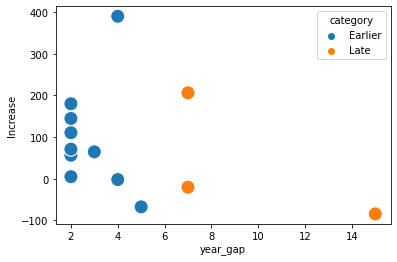

```python
sns.scatterplot(x='year_gap', y='Increase', hue='category',data=india_df, s=200)
```

According to this scatterplot, it seems that the smaller the year gap between a movie and its sequel, the more likely it is for the gross to have increased or earn around the same as its prequel. There are a only a few late sequels and two of them show a decrease in gross, while one shows a dramatic increase. Overall, it seems that the earlier sequels mostly increase in gross or stay around the same as its prequel.

There are a few outliers such as the sequel that was released 7 years after its prequel and increased by 200%. This may affect the average gross increase for late sequels dramatically.

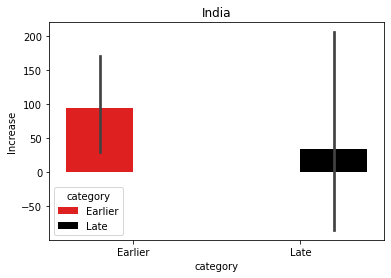

```python
sns.barplot(x='category', y='Increase', hue='category',data=india_df, palette=['red','black'])
plt.title('India')
plt.show()
```

From the bar graph above showing the increase in percentage of late sequels and sequels released before 7 years, it seems that sequels that release before 7 years have been more successful. There is actually a smaller amount of late sequels and this affects the data in a way such that this isn't the most accurate depiction of how successful late sequels are.

## **Chinese Sequel Films**

data retrieved from https://www.boxofficemojo.com/

```python
# china_seq contains the sequels only, not the first original movie.
china_seq = ["Detective Chinatown 2", "Detective Chinatown 3", "Shock Wave 2"
        , "The Four 2", "The Four 3", "Master Z: The Ip Man Legacy", "Ip Man 4: The Finale"
             , "Black Mask 2: City of Masks", "The Monkey King 2", "The Monkey King 3"]

# list1 through list6 each have a different seriese
# years1 through years6 each have the corresponding series' release year
# gross1 through gross6 each contain the corresponding series' gross

list1 = ["Detective Chinatown", "Detective Chinatown 2", "Detective Chinatown 3"]
years1 = [2015, 2018, 2021]
gross1 = [125112232, 541406438, 685070000]

list2 = ["Shock Wave", "Shock Wave 2"]
years2 = [2017, 2020]
gross2 = [58716549 , 196000000]

list3 = ["The Four", "The Four 2", "The Four 3"]
years3 = [2012, 2013, 2014]
gross3 = [29567632, 28170000, 31090000]

list4 = ["Ip Man 3","Master Z: The Ip Man Legacy", "Ip Man 4: The Finale"]
years4 = [2015, 2018, 2019]
gross4 = [124101198, 19490366, 165290606]

list5 = ["Black Mask","Black Mask 2: City of Masks"]
years5 = [1996, 2002]
gross5 = [12504289, 529322]

list6 = ["The Monkey King Havoc in Heavens Palace" ,"The Monkey King 2", "The Monkey King 3"]
years6 = [2014, 2016, 2018]
gross6 = [174187492, 185402420, 114778320]


# Concatenating all of the movie data above in order to build the table
chinese_movies = list1 + list2 + list3 + list4 + list5 + list6
grossed2 = gross1 + gross2 + gross3 + gross4 + gross5 + gross6
released2 = years1 + years2 + years3 + years4 + years5 + years6

CH_table = pd.DataFrame(chinese_movies, columns = ["Title"])
CH_table["Year"] = released2
CH_table["Gross"] = grossed2

CH_table
```

|  | Title | Year | Gross |
| --- | --- | --- | --- |
| 0 | Detective Chinatown | 2015 | 125112232 |
| 1 | Detective Chinatown 2 | 2018 | 541406438 |
| 2 | Detective Chinatown 3 | 2021 | 685070000 |
| 3 | Shock Wave | 2017 | 58716549 |
| 4 | Shock Wave 2 | 2020 | 196000000 |
| 5 | The Four | 2012 | 29567632 |
| 6 | The Four 2 | 2013 | 28170000 |
| 7 | The Four 3 | 2014 | 31090000 |
| 8 | Ip Man 3 | 2015 | 124101198 |
| 9 | Master Z: The Ip Man Legacy | 2018 | 19490366 |
| 10 | Ip Man 4: The Finale | 2019 | 165290606 |
| 11 | Black Mask | 1996 | 12504289 |
| 12 | Black Mask 2: City of Masks | 2002 | 529322 |
| 13 | The Monkey King Havoc in Heavens Palace | 2014 | 174187492 |
| 14 | The Monkey King 2 | 2016 | 185402420 |
| 15 | The Monkey King 3 | 2018 | 114778320 |

## Now, for each series we calculate:

- The difference in gross between a movie and its sequel
- The gross increase perentage between each movie and its sequel
- The number of years between the release dates of each movie and its sequel

```python
change_list = []    # Will contain a list of gross increase percentage
year_gap_chi = []   # Will contain the years gap between each movie and its sequel

#Finding the gross difference: first sequel - OG, and second sequel - first sequel

for i in range(1, 3):
    diff = gross1[i] - gross1[i-1]
    year_gap_chi.append(years1[i] - years1[i-1])
    increase = (diff * 100) / gross1[i-1]      # Calculating percentage
    change_list.append(increase)

for i in range(1, 2):
    diff = gross2[i] - gross2[i-1]
    year_gap_chi.append(years2[i] - years2[i-1])
    increase = (diff * 100) / gross2[i-1]
    change_list.append(increase)

for i in range(1, 3):
    diff = gross3[i] - gross3[i-1]
    year_gap_chi.append(years3[i] - years3[i-1])
    increase = (diff * 100) / gross3[i-1]
    change_list.append(increase)

for i in range(1, 3):
    diff = gross4[i] - gross4[i-1]
    year_gap_chi.append(years4[i] - years4[i-1])
    increase = (diff * 100) / gross4[i-1]
    change_list.append(increase)

for i in range(1, 2):
    diff = gross5[i] - gross5[i-1]
    year_gap_chi.append(years5[i] - years5[i-1])
    increase = (diff * 100) / gross5[i-1]
    change_list.append(increase)

for i in range(1, 3):
    diff = gross6[i] - gross6[i-1]
    year_gap_chi.append(years6[i] - years6[i-1])
    increase = (diff * 100) / gross6[i-1]
    change_list.append(increase)



change_list
```

```
[332.73661523359283,
 26.535251876705612,
 233.80708392790592,
 -4.7268986572884835,
 10.365637202697906,
 -84.29478013580497,
 748.0631200050323,
 -95.76687646934583,
 6.438423259461133,
 -38.09232910767832]
```

# Putting together the table containing change in gross, year gap, and categorizing by how late

```python
# china_df is the table containing the Chinese sequels and:
# column "Increase" to display the change in gross
# column "year_gap" to display the number of years it took to release after previous movie

china_df = pd.DataFrame(china_seq, columns = ["Sequels"])
china_df["Increase"] = change_list
china_df["year_gap"] = year_gap_chi
categ = []

# Categorizing year gap as released late or before 7 years
for i in range(0, len(china_df)):
    if china_df.year_gap[i] >= 7:
        categ.append("Late")
    else:
        categ.append("Earlier")


china_df["category"] = categ
china_df
```

|  | Sequels | Increase | year_gap | category |
| --- | --- | --- | --- | --- |
| 0 | Detective Chinatown 2 | 332.736615 | 3 | Earlier |
| 1 | Detective Chinatown 3 | 26.535252 | 3 | Earlier |
| 2 | Shock Wave 2 | 233.807084 | 3 | Earlier |
| 3 | The Four 2 | -4.726899 | 1 | Earlier |
| 4 | The Four 3 | 10.365637 | 1 | Earlier |
| 5 | Master Z: The Ip Man Legacy | -84.294780 | 3 | Earlier |
| 6 | Ip Man 4: The Finale | 748.063120 | 1 | Earlier |
| 7 | Black Mask 2: City of Masks | -95.766876 | 6 | Earlier |
| 8 | The Monkey King 2 | 6.438423 | 2 | Earlier |
| 9 | The Monkey King 3 | -38.092329 | 2 | Earlier |

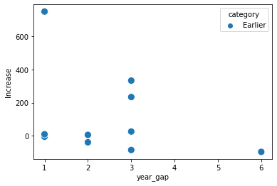

```python
sns.scatterplot(x='year_gap', y='Increase', hue='category', data=china_df, s=100)
```

China's movie sequel data does not include sequels after 7 years. It was difficult to find sequels that had late time gaps from its prequels. With this table, we can examine the trend as the gap increases. There is one sequel that had a gap of 6 years and its gross decreased the most of all other sequels in the data set. It seems that sequels that were released within 3 years had the most success of having an increase or a gross close to the same as its prequel.

The data for India and China are both not strong enough to draw big conclusions, however it can be seen that earlier sequels did bit better. The China dataset does not contain any sequels released after 7 years, but 6 years at the latest. The sequels with a 6 year gap was not as successful as the other sequels in the data set. With the little data we have of India and China, we can see that the earlier sequels have a good success rate.

# Conclusion